```
                #UDACITY DATA-ANALYST NANODEGREE
```

## P4: Exploratory Data Analysis of Quality of Red Wines by Shreyas Ramnath

In this project, I analyzed the Udacity curated red wine dataset, to find out how the chemical compositions inherently influence the quality of the red wine.

## Statistical Summary

### Structure of the dataset

```
## 'data.frame':    1599 obs. of  13 variables:
##  $ X                   : int  1 2 3 4 5 6 7 8 9 10 ...
##  $ fixed.acidity       : num  7.4 7.8 7.8 11.2 7.4 7.4 7.9 7.3 7.8 7.5 ...
##  $ volatile.acidity    : num  0.7 0.88 0.76 0.28 0.7 0.66 0.6 0.65 0.58 0.5 ...
##  $ citric.acid         : num  0 0 0.04 0.56 0 0 0.06 0 0.02 0.36 ...
##  $ residual.sugar      : num  1.9 2.6 2.3 1.9 1.9 1.8 1.6 1.2 2 6.1 ...
##  $ chlorides           : num  0.076 0.098 0.092 0.075 0.076 0.075 0.069 0.065 0.073 0.071 ...
##  $ free.sulfur.dioxide : num  11 25 15 17 11 13 15 15 9 17 ...
##  $ total.sulfur.dioxide: num  34 67 54 60 34 40 59 21 18 102 ...
##  $ density             : num  0.998 0.997 0.997 0.998 0.998 ...
##  $ pH                  : num  3.51 3.2 3.26 3.16 3.51 3.51 3.3 3.39 3.36 3.35 ...
##  $ sulphates           : num  0.56 0.68 0.65 0.58 0.56 0.56 0.46 0.47 0.57 0.8 ...
##  $ alcohol             : num  9.4 9.8 9.8 9.8 9.4 9.4 9.4 10 9.5 10.5 ...
##  $ quality             : int  5 5 5 6 5 5 5 7 7 5 ...
```

### Summary of the variables in the dataset

```
##        X          fixed.acidity   volatile.acidity  citric.acid
##  Min.   :   1.0   Min.   : 4.60   Min.   :0.1200   Min.   :0.000
##  1st Qu.: 400.5   1st Qu.: 7.10   1st Qu.:0.3900   1st Qu.:0.090
##  Median : 800.0   Median : 7.90   Median :0.5200   Median :0.260
##  Mean   : 800.0   Mean   : 8.32   Mean   :0.5278   Mean   :0.271
##  3rd Qu.:1199.5   3rd Qu.: 9.20   3rd Qu.:0.6400   3rd Qu.:0.420
##  Max.   :1599.0   Max.   :15.90   Max.   :1.5800   Max.   :1.000
##  residual.sugar     chlorides       free.sulfur.dioxide
##  Min.   : 0.900   Min.   :0.01200   Min.   : 1.00
##  1st Qu.: 1.900   1st Qu.:0.07000   1st Qu.: 7.00
##  Median : 2.200   Median :0.07900   Median :14.00
##  Mean   : 2.539   Mean   :0.08747   Mean   :15.87
##  3rd Qu.: 2.600   3rd Qu.:0.09000   3rd Qu.:21.00
##  Max.   :15.500   Max.   :0.61100   Max.   :72.00
##  total.sulfur.dioxide    density             pH          sulphates
##  Min.   :  6.00       Min.   :0.9901   Min.   :2.740   Min.   :0.3300
##  1st Qu.: 22.00       1st Qu.:0.9956   1st Qu.:3.210   1st Qu.:0.5500
##  Median : 38.00       Median :0.9968   Median :3.310   Median :0.6200
##  Mean   : 46.47       Mean   :0.9967   Mean   :3.311   Mean   :0.6581
##  3rd Qu.: 62.00       3rd Qu.:0.9978   3rd Qu.:3.400   3rd Qu.:0.7300
##  Max.   :289.00       Max.   :1.0037   Max.   :4.010   Max.   :2.0000
##     alcohol         quality
##  Min.   : 8.40   Min.   :3.000
##  1st Qu.: 9.50   1st Qu.:5.000
##  Median :10.20   Median :6.000
##  Mean   :10.42   Mean   :5.636
##  3rd Qu.:11.10   3rd Qu.:6.000
##  Max.   :14.90   Max.   :8.000
```

We plot the quality variable since that is the main factor we are interested in analyzing.

```
##    Min. 1st Qu.  Median    Mean 3rd Qu.    Max.
##   3.000   5.000   6.000   5.636   6.000   8.000
```

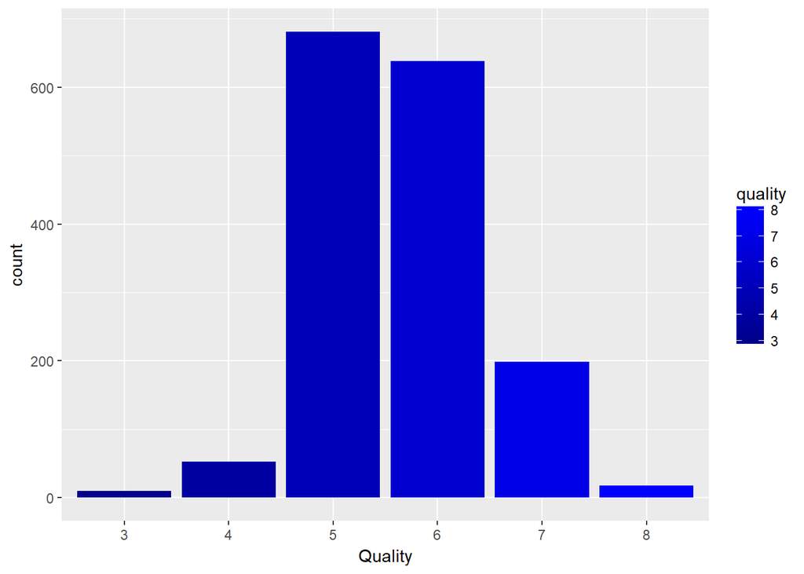

The quality variable value in the dataset is in the closed interval [3,8], with a mean value of 5.63.

## Univariate plot section

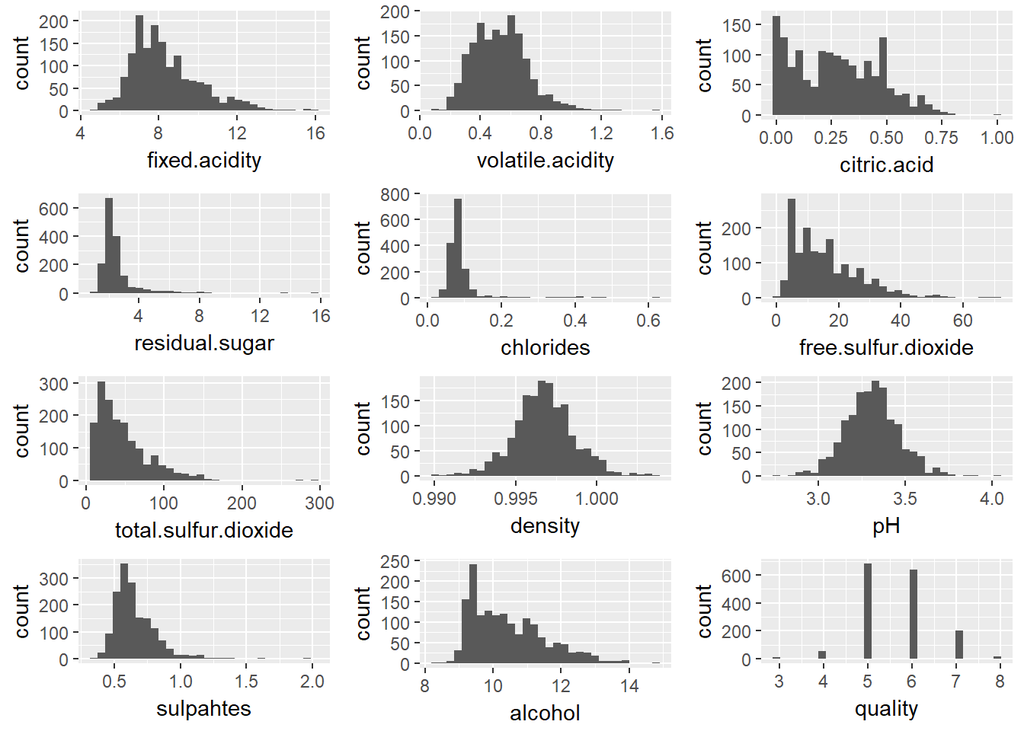

From the plots, we can observe that, as count increases the fixed acidity content also increases and once count maxes out at roughly a value of 200, then goes on reducing as the fixed acidity content in the wine increases. In the plot of count vs density and ph, the plots almost have a normal distribution. We can see that at 0.1 quantity of chlorides the count value maxes out at a value of 775. Not much could be inferred from the plot between the quality and the count variables.

The boxplots depicting outliers for some features of the wine is shown below

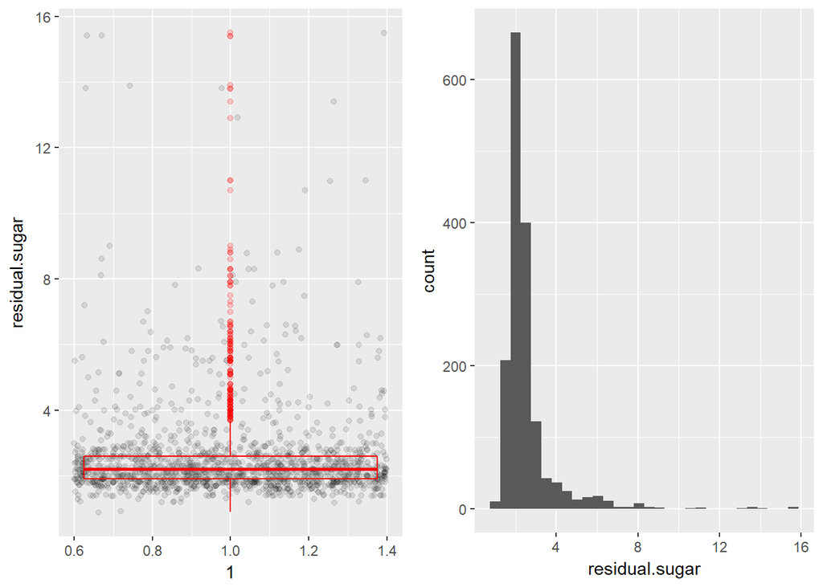

From the plot, we can observe that for lower values of residual sugar the count value is exceptionally high. And it is evident that as the residual sugar content increases in the wine the count value decreases. And almost becomes zero for residual sugar values after 8.

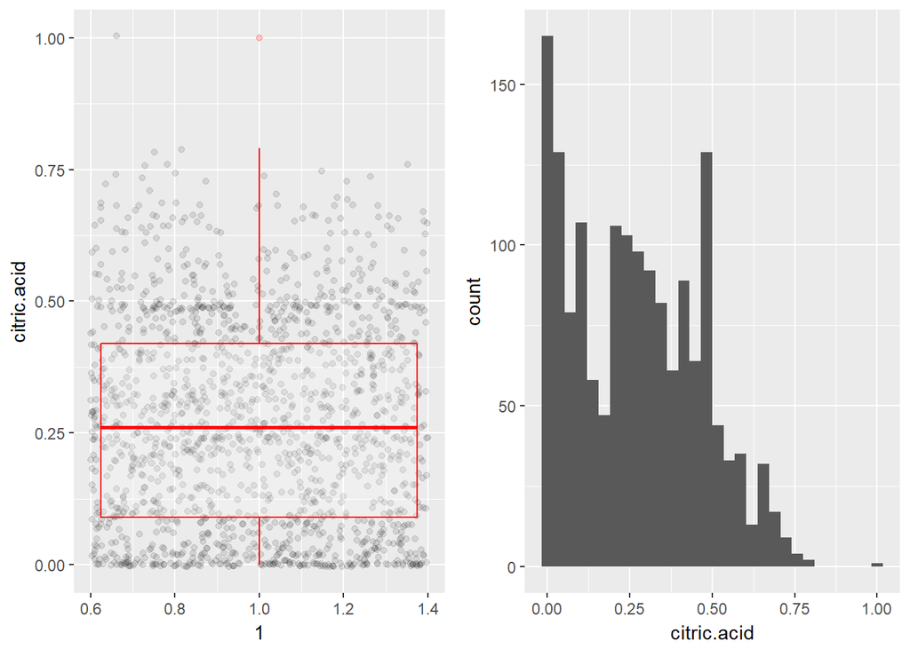

With the absence of citric acid in the wine, the count value is at its maximum value. As the citric acid content increases, the count value does drop for sometimes, but at 0.50, the count value increases and subsequently goes on decreasing as the citric acidity value of the wine increases.

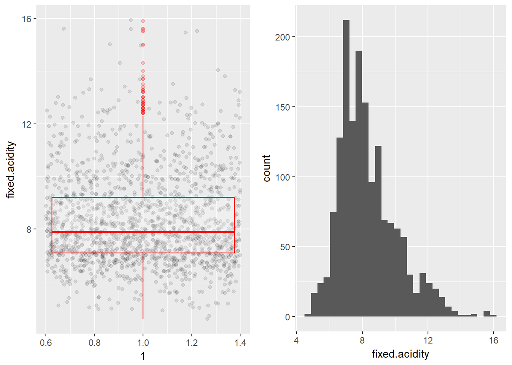

In the closed interval of [4,12] of fixed acidity, the count value is at its maximum, and is almost negligible for other value of fixed acidity in the wine sample.

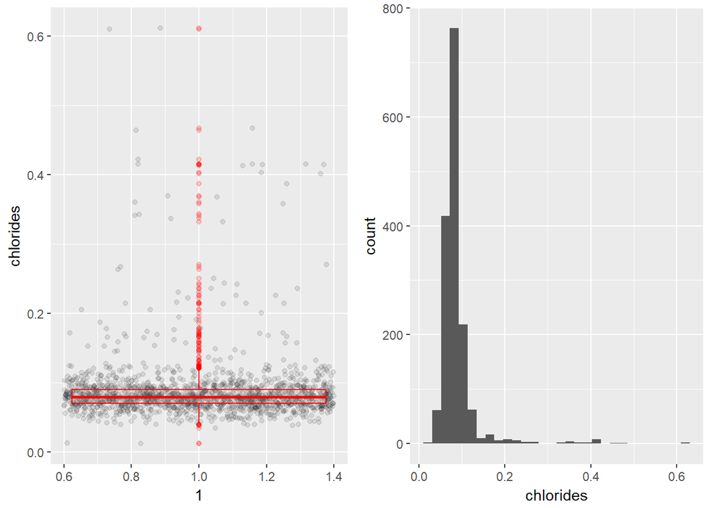

## Univariate Analysis

### Quality of wine

It is clearly evident that the wine quality range approximately falls between 3 and 8 with 5 and 6 being the most frequent ones. To deal with this we categorize the quality into three types, poor, good and best and create another variable called rating. 0 - 4: poor 5 - 6: good 7 - 10: best

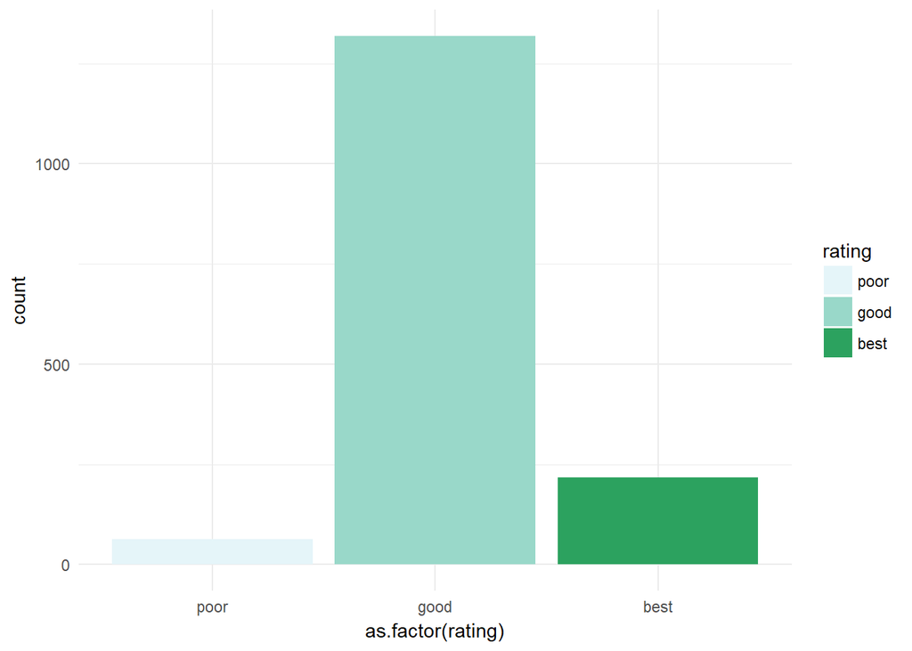

Majority of the entries in the dataset fall under the good category. The best the category has a sizeable number of data values and the poor wine category has the least.

### Summary of rating

```
## poor good best
##   63 1319  217
```

### Total acidity

create a new variable called total.acidity to calculate the sum of all acids.

```
## [1]  8.10  8.68  8.60 12.04  8.10  8.06
```

Here a variable total acidity is created to hold the values of summation of all acids present in the wine. The values can be seen above.